# Final Assignment- Practical Machine Learning

Avizit Chandra Adhikary

January 25, 2019

Loading training and test data sets

```r
training <- read.csv("https://d396qusza40orc.cloudfront.net/predmachlearn/pml-training.csv")
testing <- read.csv("https://d396qusza40orc.cloudfront.net/predmachlearn/pml-testing.csv")
```

Checking for relations between response and probable predictors (detailed codes are skipped):

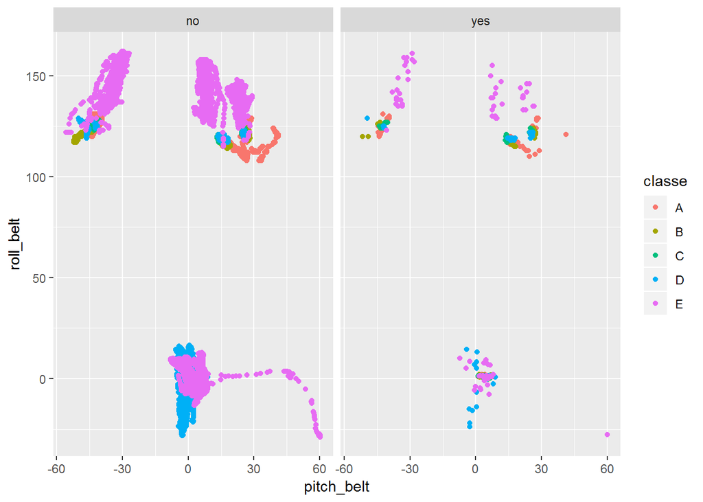

```r
var.name <- names(training)
var.name <- gsub(var.name, pattern = "roll_belt.1", replacement = "pitch_belt" )

library(ggplot2)

## belt vs classe
ggplot(training, aes( x=pitch_belt, y=roll_belt, color=classe))+ geom_point()+facet_grid(.~training$new_window) ### Some pattern
```

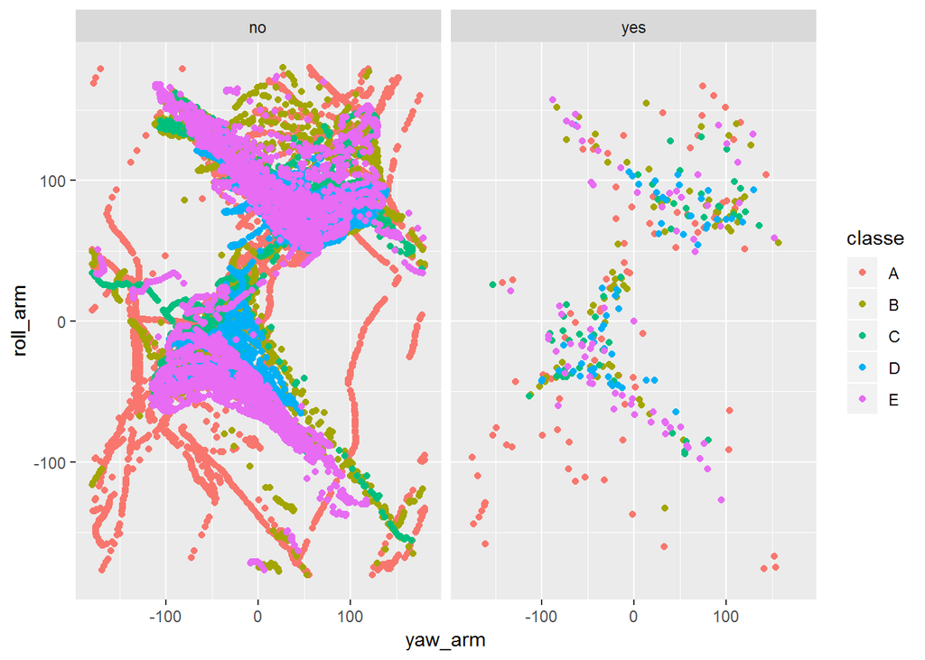

```r
## arm vs classe
ggplot(training, aes( x=yaw_arm, y=roll_arm, color=classe)) + geom_point()+facet_grid(.~training$new_window) ### Some pattern
```

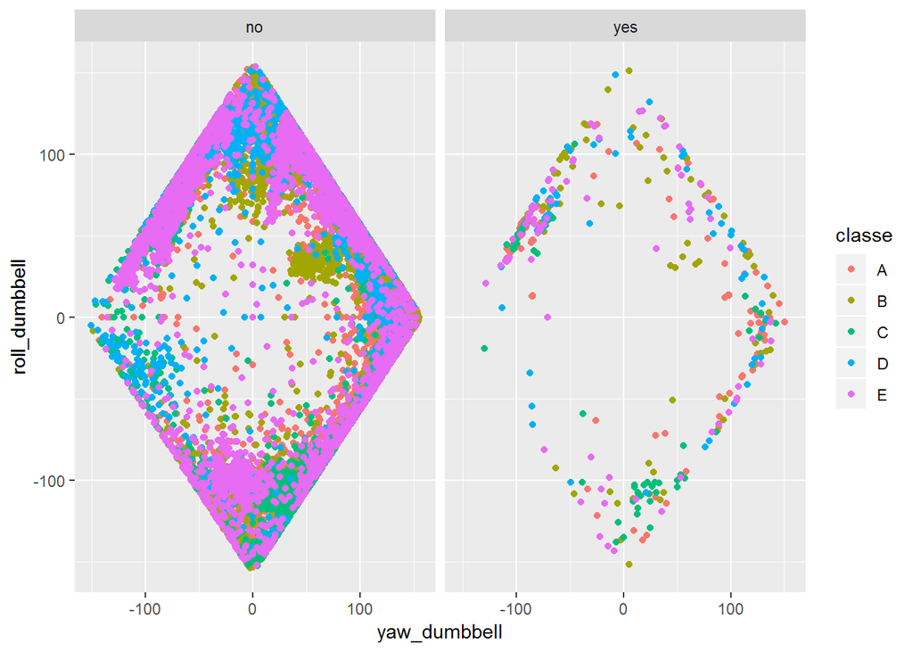

```r
## Dumbbell vs classe
ggplot(training, aes( x=yaw_dumbbell, y=roll_dumbbell, color=classe)) + geom_point()+facet_grid(.~training$new_window) ###Some pattern
```

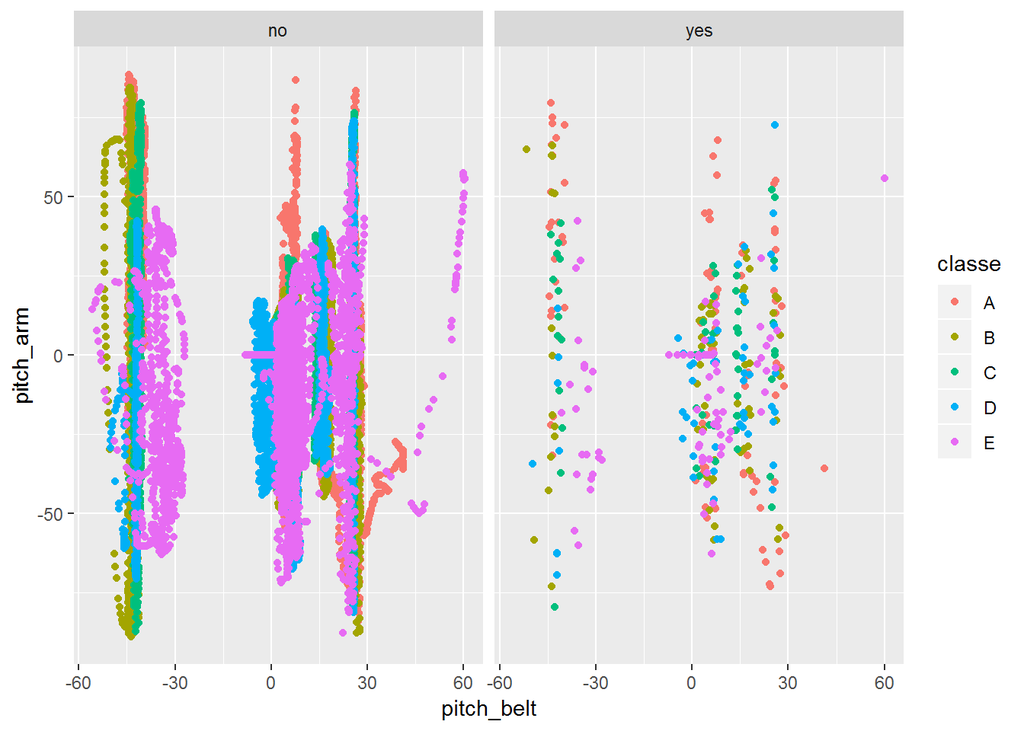

```r
#### Pattern searching within pitch, roll, yaw, gyros
ggplot(training, aes( x=pitch_belt, y=pitch_arm, color=classe)) + geom_point()+facet_grid(.~training$new_window) ### No pattern
```

After exploratory data analysis, it got clear that some of the main variables (like roll, pitch, yaw, gyros, accel, magnet for each of arm, forearm, belt, dumbbell) show some patters with classe, while some show no pattern. Also, when new_window=“yes”, then we get values for some additional variables (mean, min, max, total etc.), but they don’t show any observable patters. So, these additional variables have been omitted in further analysis. Correlation among these main variables for each of arm, belt, forearm, dumbbell are checked next (detailed codes are omitted):

```r
### correlation checking for belt variables

correlation.matrix <-cor(cbind(training$roll_belt, training$pitch_belt, training$yaw_belt,
            training$accel_belt_x, training$accel_belt_y, training$accel_belt_z,
            training$gyros_belt_x, training$gyros_belt_y, training$gyros_belt_z,
            training$magnet_belt_x, training$magnet_belt_y, training$magnet_belt_z))

diag(correlation.matrix) <- 0
correlation.matrix[which(correlation.matrix>0.8, arr.ind = TRUE)]
```

```
## [1] 0.8152297 0.9248983 0.8152297 0.8920913 0.9248983 0.8920913
```

From the correlation matrix, we can see that some variables are correlated more than 80%. To remove the correlation among the variables, Principal Component analysis is conducted on the main variables (gyros, accel, magnet for each of arm, forearm, belt, dumbbell) on the training set and then mapped on the testing set. Prinicipal components are retained till 90% variation explained.

```r
################################### PCA Creation for training and testing set

library(caret)
############## PCA For ARM #############
pca_gyros_arm <- preProcess( training[,grep("gyros_arm", names(training))], method = "pca", thresh = 0.9)
pca_gyros_arm$rotation### 2 PCs
```

```
##                    PC1        PC2
## gyros_arm_x  0.6220497  0.4036122
## gyros_arm_y -0.6515644 -0.2083405
## gyros_arm_z  0.4341866 -0.8908936
```

```r
pca_gyros_arm_train <- predict(pca_gyros_arm, training[,grep("gyros_arm", names(training))])
cor(pca_gyros_arm_train) ### No correlation exists
```

```
##               PC1           PC2
## PC1  1.000000e+00 -6.267324e-17
## PC2 -6.267324e-17  1.000000e+00
```

```r
pca_gyros_arm_test <- predict(pca_gyros_arm, testing[,grep("gyros_arm", names(testing))])

pca_accel_arm <- preProcess( training[,grep("^accel_arm", names(training))], method = "pca", thresh = 0.9)
#pca_accel_arm$rotation
pca_accel_arm_train <- predict(pca_accel_arm, training[,grep("^accel_arm", names(training))])### 3 PCs
pca_accel_arm_test <- predict(pca_accel_arm, testing[,grep("^accel_arm", names(testing))])


pca_magnet_arm <- preProcess( training[,grep("^magnet_arm", names(training))], method = "pca", thresh = 0.9)
#pca_magnet_arm$rotation
pca_magnet_arm_train <- predict(pca_magnet_arm, training[,grep("^magnet_arm", names(training))])### 2 PCs
pca_magnet_arm_test <- predict(pca_magnet_arm, testing[,grep("^magnet_arm", names(testing))])


############## PCA For BELT #############
pca_gyros_belt <- preProcess( training[,grep("gyros_belt", names(training))], method = "pca", thresh = 0.9)
#pca_gyros_belt$rotation
pca_gyros_belt_train <- predict(pca_gyros_belt, training[,grep("gyros_belt", names(training))])### 3 PCs
pca_gyros_belt_test <- predict(pca_gyros_belt, testing[,grep("gyros_belt", names(testing))])


pca_accel_belt <- preProcess( training[,grep("^accel_belt", names(training))], method = "pca", thresh = 0.9)
#pca_accel_belt$rotation
pca_accel_belt_train <- predict(pca_accel_belt, training[,grep("^accel_belt", names(training))])### 2 PCs
pca_accel_belt_test <- predict(pca_accel_belt, testing[,grep("^accel_belt", names(testing))])


pca_magnet_belt <- preProcess( training[,grep("^magnet_belt", names(training))], method = "pca", thresh = 0.9)
pca_magnet_belt$rotation
```

```
##                      PC1         PC2
## magnet_belt_x 0.06012495 -0.98775353
## magnet_belt_y 0.70267216  0.14432418
## magnet_belt_z 0.70896884 -0.05927474
```

```r
pca_magnet_belt_train <- predict(pca_magnet_belt, training[,grep("^magnet_belt", names(training))])### 2 PCs
pca_magnet_belt_test <- predict(pca_magnet_belt, testing[,grep("^magnet_belt", names(testing))])


############## PCA For FOREARM #############
pca_gyros_forearm <- preProcess( training[,grep("gyros_forearm", names(training))], method = "pca", thresh = 0.9)
pca_gyros_forearm$rotation
```

```
##                        PC1        PC2
## gyros_forearm_x  0.4163743 -0.8921643
## gyros_forearm_y -0.6626306 -0.1658737
## gyros_forearm_z -0.6225376 -0.4201534
```

```r
pca_gyros_forearm_train <- predict(pca_gyros_forearm, training[,grep("gyros_forearm", names(training))])
#cor(pca_gyros_forearm_train) ### 2 PCs
pca_gyros_forearm_test <- predict(pca_gyros_forearm, testing[,grep("gyros_forearm", names(testing))])


pca_accel_forearm <- preProcess( training[,grep("^accel_forearm", names(training))], method = "pca", thresh = 0.9)
pca_accel_forearm$rotation
```

```
##                        PC1        PC2        PC3
## accel_forearm_x  0.7241419 -0.0447626  0.6881967
## accel_forearm_y  0.5944436  0.5464395 -0.5899497
## accel_forearm_z -0.3496502  0.8363015  0.4223086
```

```r
pca_accel_forearm_train <- predict(pca_accel_forearm, training[,grep("^accel_forearm", names(training))])
#cor(pca_accel_forearm_train) ### 3 PCs
pca_accel_forearm_test <- predict(pca_accel_forearm, testing[,grep("^accel_forearm", names(testing))])


pca_magnet_forearm <- preProcess( training[,grep("^magnet_forearm", names(training))], method = "pca", thresh = 0.9)
pca_magnet_forearm$rotation
```

```
##                         PC1         PC2        PC3
## magnet_forearm_x -0.5702651  0.60349617  0.5573060
## magnet_forearm_y  0.6473836 -0.08744628  0.7571312
## magnet_forearm_z  0.5056601  0.79255632 -0.3408259
```

```r
pca_magnet_forearm_train <- predict(pca_magnet_forearm, training[,grep("^magnet_forearm", names(training))])
#cor(pca_magnet_forearm_train) ### 3 PCs
pca_magnet_forearm_test <- predict(pca_magnet_forearm, testing[,grep("^magnet_forearm", names(testing))])



############## PCA For Dumbbel #############
pca_gyros_dumbbell <- preProcess( training[,grep("gyros_dumbbell", names(training))], method = "pca", thresh = 0.9)
pca_gyros_dumbbell$rotation
```

```
##                         PC1        PC2
## gyros_dumbbell_x  0.6119245 -0.3039382
## gyros_dumbbell_y -0.5157202 -0.8532886
## gyros_dumbbell_z -0.5996508  0.4236981
```

```r
pca_gyros_dumbbell_train <- predict(pca_gyros_dumbbell, training[,grep("gyros_dumbbell",names(training))])
pca_gyros_dumbbell_test <- predict(pca_gyros_dumbbell, testing[,grep("gyros_dumbbell", names(testing))])


pca_accel_dumbbell <- preProcess( training[,grep("^accel_dumbbell", names(training))], method = "pca", thresh = 0.9)
pca_accel_dumbbell$rotation
```

```
##                         PC1         PC2
## accel_dumbbell_x  0.5544795 -0.68700081
## accel_dumbbell_y -0.5450554 -0.72626877
## accel_dumbbell_z  0.6288618 -0.02373951
```

```r
pca_accel_dumbbell_train <- predict(pca_accel_dumbbell, training[,grep("^accel_dumbbell", names(training))])
pca_accel_dumbbell_test <- predict(pca_accel_dumbbell, testing[,grep("^accel_dumbbell", names(testing))])


pca_magnet_dumbbell <- preProcess( training[,grep("^magnet_dumbbell",names(training))], method = "pca", thresh = 0.9)
pca_magnet_dumbbell_train <- predict(pca_magnet_dumbbell, training[,grep("^magnet_dumbbell", names(training))])
pca_magnet_dumbbell_test <- predict(pca_magnet_dumbbell, testing[,grep("^magnet_dumbbell", names(testing))])
```

After PCAs are created for both training and testing set, we create “build.data” containing main variables and PCAs. We fit Random forest and Boosting models on the “build.data” data where, “classe” is the response-class variable and all other main variables including PCAs are explanatory variables.

```r
###################### Model Fitting ###################

pitch.index <- grep("^pitch", var.name)
roll.index <-  grep("^roll", var.name)
yaw.index <-  grep("^yaw", var.name)


####### Training Test

training$pca_gyros_arm.PC1 <- pca_gyros_arm_train$PC1
training$pca_gyros_arm.PC2 <- pca_gyros_arm_train$PC2

training$pca_accel_arm.PC1 <- pca_accel_arm_train$PC1
training$pca_accel_arm.PC2 <- pca_accel_arm_train$PC2
training$pca_accel_arm.PC3 <- pca_accel_arm_train$PC3

training$pca_magnet_arm.PC1 <- pca_magnet_arm_train$PC1
training$pca_magnet_arm.PC2 <- pca_magnet_arm_train$PC2

training$pca_gyros_belt.PC1 <- pca_gyros_belt_train$PC1
training$pca_gyros_belt.PC2 <- pca_gyros_belt_train$PC2
training$pca_gyros_belt.PC3 <- pca_gyros_belt_train$PC3

training$pca_accel_belt.PC1 <- pca_accel_belt_train$PC1
training$pca_accel_belt.PC2 <- pca_accel_belt_train$PC2

training$pca_magnet_belt.PC1 <- pca_magnet_belt_train$PC1
training$pca_magnet_belt.PC2 <- pca_magnet_belt_train$PC2

training$pca_gyros_forearm.PC1 <- pca_gyros_forearm_train$PC1
training$pca_gyros_forearm.PC2 <- pca_gyros_forearm_train$PC2

training$pca_accel_forearm.PC1 <- pca_accel_forearm_train$PC1
training$pca_accel_forearm.PC2 <- pca_accel_forearm_train$PC2
training$pca_accel_forearm.PC3 <- pca_accel_forearm_train$PC3

training$pca_magnet_forearm.PC1 <- pca_magnet_forearm_train$PC1
training$pca_magnet_forearm.PC2 <- pca_magnet_forearm_train$PC2
training$pca_magnet_forearm.PC3 <- pca_magnet_forearm_train$PC3

training$pca_gyros_dumbbell.PC1 <- pca_gyros_dumbbell_train$PC1
training$pca_gyros_dumbbell.PC2 <- pca_gyros_dumbbell_train$PC2

training$pca_accel_dumbbell.PC1 <- pca_accel_dumbbell_train$PC1
training$pca_accel_dumbbell.PC2 <- pca_accel_dumbbell_train$PC2

training$pca_magnet_dumbbell.PC1 <- pca_magnet_dumbbell_train$PC1
training$pca_magnet_dumbbell.PC2 <- pca_magnet_dumbbell_train$PC2


###### PCA for Testing Set

testing$pca_gyros_arm.PC1 <- pca_gyros_arm_test$PC1
testing$pca_gyros_arm.PC2 <- pca_gyros_arm_test$PC2

testing$pca_accel_arm.PC1 <- pca_accel_arm_test$PC1
testing$pca_accel_arm.PC2 <- pca_accel_arm_test$PC2
testing$pca_accel_arm.PC3 <- pca_accel_arm_test$PC3

testing$pca_magnet_arm.PC1 <- pca_magnet_arm_test$PC1
testing$pca_magnet_arm.PC2 <- pca_magnet_arm_test$PC2

testing$pca_gyros_belt.PC1 <- pca_gyros_belt_test$PC1
testing$pca_gyros_belt.PC2 <- pca_gyros_belt_test$PC2
testing$pca_gyros_belt.PC3 <- pca_gyros_belt_test$PC3

testing$pca_accel_belt.PC1 <- pca_accel_belt_test$PC1
testing$pca_accel_belt.PC2 <- pca_accel_belt_test$PC2

testing$pca_magnet_belt.PC1 <- pca_magnet_belt_test$PC1
testing$pca_magnet_belt.PC2 <- pca_magnet_belt_test$PC2

testing$pca_gyros_forearm.PC1 <- pca_gyros_forearm_test$PC1
testing$pca_gyros_forearm.PC2 <- pca_gyros_forearm_test$PC2

testing$pca_accel_forearm.PC1 <- pca_accel_forearm_test$PC1
testing$pca_accel_forearm.PC2 <- pca_accel_forearm_test$PC2
testing$pca_accel_forearm.PC3 <- pca_accel_forearm_test$PC3

testing$pca_magnet_forearm.PC1 <- pca_magnet_forearm_test$PC1
testing$pca_magnet_forearm.PC2 <- pca_magnet_forearm_test$PC2
testing$pca_magnet_forearm.PC3 <- pca_magnet_forearm_test$PC3

testing$pca_gyros_dumbbell.PC1 <- pca_gyros_dumbbell_test$PC1
testing$pca_gyros_dumbbell.PC2 <- pca_gyros_dumbbell_test$PC2

testing$pca_accel_dumbbell.PC1 <- pca_accel_dumbbell_test$PC1
testing$pca_accel_dumbbell.PC2 <- pca_accel_dumbbell_test$PC2

testing$pca_magnet_dumbbell.PC1 <- pca_magnet_dumbbell_test$PC1
testing$pca_magnet_dumbbell.PC2 <- pca_magnet_dumbbell_test$PC2


pca.index <- grep("^pca", names(training))
build.data <- training[,c(160, pitch.index, roll.index, yaw.index, pca.index)]

library(randomForest)
library(caret)

### Training Random Forest Model
model.rf <- randomForest(classe~., data=build.data)
model.rf
```

```
##
## Call:
##  randomForest(formula = classe ~ ., data = build.data)
##                Type of random forest: classification
##                      Number of trees: 500
## No. of variables tried at each split: 6
##
##         OOB estimate of  error rate: 0.36%
## Confusion matrix:
##      A    B    C    D    E  class.error
## A 5576    3    0    0    1 0.0007168459
## B   10 3784    3    0    0 0.0034237556
## C    0   11 3400   11    0 0.0064289889
## D    0    1   20 3193    2 0.0071517413
## E    0    0    2    7 3598 0.0024951483
```

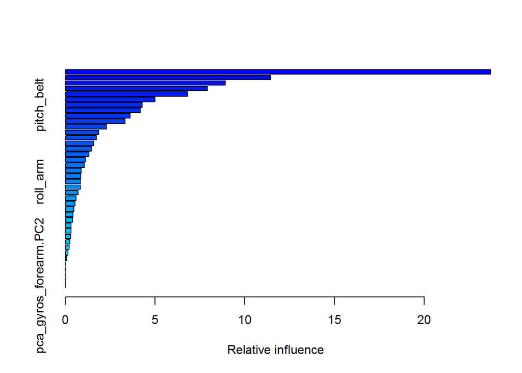

```
##                                             var     rel.inf
## roll_belt                             roll_belt 23.68932679
## pitch_forearm                     pitch_forearm 11.45486325
## pca_magnet_dumbbell.PC2 pca_magnet_dumbbell.PC2  8.91751110
## yaw_belt                               yaw_belt  7.93015393
## pca_accel_dumbbell.PC2   pca_accel_dumbbell.PC2  6.82615086
## roll_forearm                       roll_forearm  5.00993777
## pitch_belt                           pitch_belt  4.29412668
## pca_magnet_belt.PC1         pca_magnet_belt.PC1  4.17011000
## roll_dumbbell                     roll_dumbbell  3.60957134
## pca_magnet_dumbbell.PC1 pca_magnet_dumbbell.PC1  3.33819746
## pca_magnet_forearm.PC3   pca_magnet_forearm.PC3  2.28616324
## pca_accel_forearm.PC3     pca_accel_forearm.PC3  1.87227996
## yaw_arm                                 yaw_arm  1.72601736
## pca_accel_arm.PC3             pca_accel_arm.PC3  1.57520936
## pca_gyros_dumbbell.PC1   pca_gyros_dumbbell.PC1  1.44929087
## pca_accel_dumbbell.PC1   pca_accel_dumbbell.PC1  1.33084310
## pca_magnet_belt.PC2         pca_magnet_belt.PC2  1.11888408
## pca_magnet_forearm.PC2   pca_magnet_forearm.PC2  1.07068543
## pca_magnet_arm.PC2           pca_magnet_arm.PC2  0.88698064
## pca_gyros_dumbbell.PC2   pca_gyros_dumbbell.PC2  0.87097101
## roll_arm                               roll_arm  0.85220478
## pca_magnet_arm.PC1           pca_magnet_arm.PC1  0.84272935
## yaw_dumbbell                       yaw_dumbbell  0.71900168
## pca_gyros_belt.PC1           pca_gyros_belt.PC1  0.60477341
## pca_accel_arm.PC2             pca_accel_arm.PC2  0.55182819
## pca_gyros_belt.PC2           pca_gyros_belt.PC2  0.48891773
## pca_gyros_belt.PC3           pca_gyros_belt.PC3  0.42768403
## pca_accel_belt.PC1           pca_accel_belt.PC1  0.41594797
## pca_accel_forearm.PC1     pca_accel_forearm.PC1  0.33524790
## pitch_dumbbell                   pitch_dumbbell  0.32112242
## pca_accel_forearm.PC2     pca_accel_forearm.PC2  0.30416386
## pca_accel_arm.PC1             pca_accel_arm.PC1  0.25618352
## yaw_forearm                         yaw_forearm  0.22271665
## pca_magnet_forearm.PC1   pca_magnet_forearm.PC1  0.14481244
## pca_gyros_arm.PC1             pca_gyros_arm.PC1  0.08539184
## pitch_arm                             pitch_arm  0.00000000
## pca_gyros_arm.PC2             pca_gyros_arm.PC2  0.00000000
## pca_accel_belt.PC2           pca_accel_belt.PC2  0.00000000
## pca_gyros_forearm.PC1     pca_gyros_forearm.PC1  0.00000000
## pca_gyros_forearm.PC2     pca_gyros_forearm.PC2  0.00000000
```

```r
### Training Boosting Model
fitControl <- trainControl(method="repeatedcv",
                           number=5,
                           repeats=1,
                           verboseIter=FALSE)

gbmFit <- train(classe ~ ., data=build.data,
                method="gbm",
                trControl=fitControl,
                verbose=FALSE)
summary(gbmFit)
```

```r
confusionMatrix(predict(gbmFit, build.data), build.data$classe)
```

```
## Confusion Matrix and Statistics
##
##           Reference
## Prediction    A    B    C    D    E
##          A 5530   85    1    6    3
##          B   35 3630   79    5   16
##          C    8   76 3309  107   30
##          D    4    3   31 3089   36
##          E    3    3    2    9 3522
##
## Overall Statistics
##
##                Accuracy : 0.9724
##                  95% CI : (0.97, 0.9746)
##     No Information Rate : 0.2844
##     P-Value [Acc > NIR] : < 2.2e-16
##
##                   Kappa : 0.9651
##  Mcnemar's Test P-Value : < 2.2e-16
##
## Statistics by Class:
##
##                      Class: A Class: B Class: C Class: D Class: E
## Sensitivity            0.9910   0.9560   0.9670   0.9605   0.9764
## Specificity            0.9932   0.9915   0.9864   0.9955   0.9989
## Pos Pred Value         0.9831   0.9641   0.9374   0.9766   0.9952
## Neg Pred Value         0.9964   0.9895   0.9930   0.9923   0.9947
## Prevalence             0.2844   0.1935   0.1744   0.1639   0.1838
## Detection Rate         0.2818   0.1850   0.1686   0.1574   0.1795
## Detection Prevalence   0.2867   0.1919   0.1799   0.1612   0.1804
## Balanced Accuracy      0.9921   0.9737   0.9767   0.9780   0.9877
```

We see that, both Random Forest and Boosting Models fit the training data well. After fitting the models, we checked how similarly both models predict “classe” on the testing data.

```r
pred.test.rf <- predict(model.rf, testing)
pred.test.boost <- predict(gbmFit, testing)
table(pred.test.rf, pred.test.boost)
```

```
##             pred.test.boost
## pred.test.rf A B C D E
##            A 7 0 0 0 0
##            B 0 7 1 0 0
##            C 0 0 1 0 0
##            D 0 0 0 1 0
##            E 0 0 0 0 3
```

```r
cbind(pred.test.rf, pred.test.boost)
```

```
##    pred.test.rf pred.test.boost
## 1             2               2
## 2             1               1
## 3             2               3
## 4             1               1
## 5             1               1
## 6             5               5
## 7             4               4
## 8             2               2
## 9             1               1
## 10            1               1
## 11            2               2
## 12            3               3
## 13            2               2
## 14            1               1
## 15            5               5
## 16            5               5
## 17            1               1
## 18            2               2
## 19            2               2
## 20            2               2
```